# Homework 2

Jenni Kane

2/12/2021

QUESTION 1

```r
beach<-read.csv(file = 'beach.csv')

beach.model<-lm(formula=OpenBeach~Year*Dummy.ID, data = beach)
summary(beach.model)
```

```
##
## Call:
## lm(formula = OpenBeach ~ Year * Dummy.ID, data = beach)
##
## Residuals:
##      Min       1Q   Median       3Q      Max
## -144.414  -33.872   -1.037   29.854  139.560
##
## Coefficients:
##                 Estimate Std. Error t value Pr(>|t|)
## (Intercept)    30360.952   3708.777   8.186 2.99e-11 ***
## Year             -15.091      1.851  -8.152 3.41e-11 ***
## Dummy.ID      -14401.978   2872.650  -5.013 5.35e-06 ***
## Year:Dummy.ID      7.193      1.434   5.016 5.29e-06 ***
## ---
## Signif. codes:  0 '***' 0.001 '**' 0.01 '*' 0.05 '.' 0.1 ' ' 1
##
## Residual standard error: 62.93 on 58 degrees of freedom
## Multiple R-squared:  0.5517, Adjusted R-squared:  0.5285
## F-statistic: 23.79 on 3 and 58 DF,  p-value: 3.64e-10
```

```r
beach.residuals<-residuals(beach.model)
summary(beach.residuals)
```

```
##     Min.  1st Qu.   Median     Mean  3rd Qu.     Max.
## -144.414  -33.872   -1.037    0.000   29.855  139.560
```

Does match the quantiles from above.

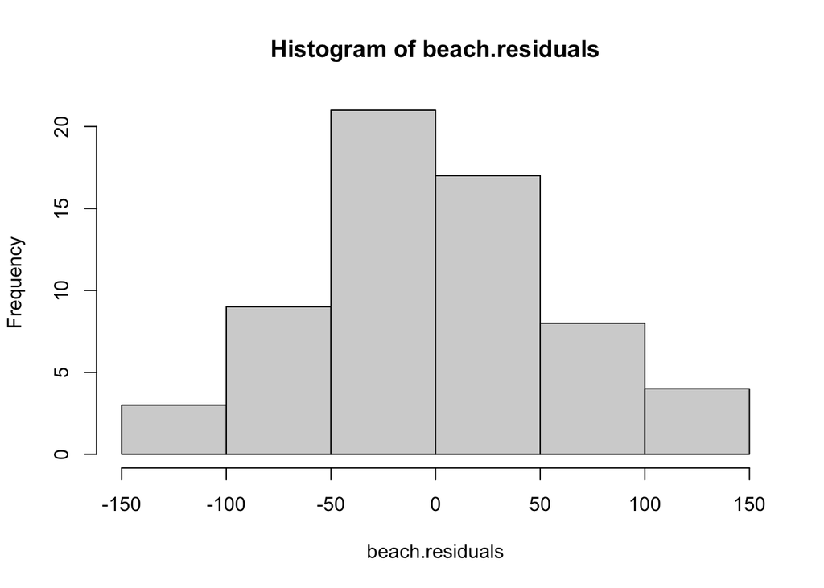

```r
hist.rediduals<-hist(beach.residuals)
```

Residuals appear reasonably Gaussian.

QUESTION 2-calculate test statistics

```r
betas<-coefficients(beach.model)
betas
```

```
##   (Intercept)          Year      Dummy.ID Year:Dummy.ID
##   30360.95227     -15.09128  -14401.97790       7.19290
```

Test statistic for year

```r
#Standard error
SE_year<-summary(beach.model)[['coefficients']]['Year', 'Std. Error']

#Null hypothesis: that there is no change over time in beach area
null_1<-0

#Test Statistic
TS_year<-(betas[2]-null_1)/SE_year
TS_year
```

```
##      Year
## -8.152045
```

Matches model output!

Test statistic for Beach ID

```r
SE_beachID<-summary(beach.model)[['coefficients']]['Dummy.ID', 'Std. Error']

#Null hypothesis: that there is no difference between beaches in beach area
null_1<-0

#Test Statistic
TS_beachID<-(betas[3]-null_1)/SE_beachID
TS_beachID
```

```
##  Dummy.ID
## -5.013481
```

Matches model output!

Test Statistic for Years*Beach ID

```r
SE_yearbyID<-summary(beach.model)[['coefficients']]['Year:Dummy.ID', 'Std. Error']

#Null hypothesis: that there is no difference in beach area over time between beaches
null_1<-0

#Test Statistic
TS_yearbyID<-(betas[4]-null_1)/SE_yearbyID
TS_yearbyID
```

```
## Year:Dummy.ID
##      5.016428
```

Matches model output!

Test statistic for Intercept

```r
SE_intercept<-summary(beach.model)[['coefficients']]['(Intercept)', 'Std. Error']

#Null hypothesis: that the line associated with the trend crosses the y axis at 0
null_1<-0

#Test Statistic
TS_intercept<-(betas[1]-null_1)/SE_intercept
TS_intercept
```

```
## (Intercept)
##    8.186244
```

Matches model output!

QUESTION 3-calculate p-values

```r
nrow(beach)
```

```
## [1] 62
```

n-k degrees of freedom would be 62-4=58 We have 58 degrees of freedom

P value for year

```r
pYear<-pt(q=TS_year, df=58)
pYear
```

```
##         Year
## 1.703821e-11
```

```r
pYear*2
```

```
##         Year
## 3.407643e-11
```

Matches Model output! The null hypothesis is that there is no change over time in beach area. We reject this null hypothesis.

P value for Beach ID

```r
pBeach<-pt(q=TS_beachID, df=58)
pBeach
```

```
##     Dummy.ID
## 2.675332e-06
```

```r
pBeach*2
```

```
##     Dummy.ID
## 5.350664e-06
```

P value for interaction of year*beach ID

```r
pBeachbyYear<-pt(q=-TS_yearbyID, df=58)
pBeachbyYear
```

```
## Year:Dummy.ID
##  2.646913e-06
```

```r
pBeachbyYear*2
```

```
## Year:Dummy.ID
##  5.293826e-06
```

Matches model output! Null hypothesis was that there is no difference in beach area over time between beaches. We reject this null hypothesis.

P value for Intercept

```r
pIntercept<-pt(q=-TS_intercept, df=58)
pIntercept
```

```
##  (Intercept)
## 1.493519e-11
```

```r
pIntercept*2
```

```
##  (Intercept)
## 2.987038e-11
```

QUESTION 4

New null hypothesis to test: That the change in beach area over time occurs at a rate of 100 hectares per year. Alternative hypothesis is that the change occurs at a rate greater than that.

```r
null_new<-100
#Test Statistic
TS_year_new<-(betas[2]-null_new)/SE_year
TS_year_new
```

```
##      Year
## -62.17031
```

```r
pYearNew<-pt(q=TS_year_new, df=58)
pYearNew
```

```
##         Year
## 4.410196e-55
```

```r
pYearNew*2
```

```
##         Year
## 8.820391e-55
```

QUESTION 5

From the whole model output, we see that the main effects of Beach ID and Year are both affecting beach area significantly as well as the interaction between the two. Hence if we calculate the rate of change at the individual beaches, we see that the rates of change are indeed distinct at each of the beaches:

Rate of change at Beach A (dummy variable 0)

```r
betas[2]+(betas[4]*0)
```

```
##      Year
## -15.09128
```

Rate of change at Beach B (dummy variable 1)

```r
betas[2]+(betas[4]*1)
```

```
##      Year
## -7.898376
```

Rate of change at Beach C (dummy variable 2)

```r
betas[2]+(betas[4]*2)
```

```
##       Year
## -0.7054767
```

At beach A, area is decreasing at a rate of ~15 hectares per year. At beach B, area is decreasing by ~8 hectares per year. At beach C, area is decreasing by ~1 hectare per year.